# xv20230816_CCD_TIF_preprocessing

x.vergara

2023-08-16

#IMPORTANT!!!!! - This is a temporary file, where I ask if TIF can be used to explain changes in pathway balance. In this file, TIF is calculated as log2(edited/non-edited)

In this document, I will go over different calculations of epistasis.4 different workflows: First decision is whether to use log2 MMEJscore or MMEJscore Second decision is comparing slopes or statistic differences between WT vs. KO slopes

```r
knitr::opts_chunk$set(root.dir = '/home/x.vergara/XV_P3_ChromDSBScreen/xv_CRISPR_screen_figures/rmarkdown/xv20210920_paper_scripts/short_version/knit_html/')

StartTime <-Sys.time()
library(knitr)

# 8-digit Date tag:
Date <- substr(gsub("-","",Sys.time()),1,8)

#Change in.dir accordingly
in.dir <- "/home/x.vergara/XV_P3_ChromDSBScreen/xv_CRISPR_screen_figures/"

#Check if output contain datetag
saveRDS_proof <- function(object, file) {
  document_path <- rstudioapi::getSourceEditorContext()$path %>% str_split(pattern = "/") %>% unlist()
  document_name <- document_path[length(document_path)]
  log_path <- paste0(in.dir,"log")
  sys_time <- Sys.time()
  if (grepl(Date, file) == T) {
    #print(mode(log_path))
    #base::write(c("test", as.character(sys_time),"Output", object), file = log_path, ncolumns = 4, sep = "\t", append = T)
    saveRDS(object, file)
  }
  else {
    print("Incorrect datetag!")
  }
}

#Read rds check through different versions
readRDS_proof <- function(path, pat) {
  full.path <- paste0(in.dir, path)
  document_path <- rstudioapi::getSourceEditorContext()$path %>% str_split(pattern = "/") %>% unlist()
  document_name <- document_path[length(document_path)]
  sys_time <- Sys.time()

  if(file.exists(full.path) == T){
    if(paste0(in.dir,path) != getwd()){
      setwd(paste0(in.dir, path))
  }
    file.list <- list.files(pattern = pat)
    correct_file <- str_sort(file.list, decreasing = T)[1]
    print(correct_file)
    write(c(document_name,as.character(sys_time) ,"Input", correct_file), file = paste0(in.dir,"log"), ncolumns = 4, sep = "\t", append = T)
    readRDS(correct_file)

  }
  else{
  setwd(path)
  file.list <- list.files(pattern = pat)
  correct_file <- str_sort(file.list, decreasing = T)[1]
  print(correct_file)
  write(c(document_name, as.character(sys_time),"Input", correct_file),file = paste0(in.dir,"log"), ncolumns = 4, sep = "\t", append = T)
  readRDS(correct_file)
  }
}
```

# Libraries

```r
# libraries:
library(tidyverse)
library(reshape2)
library(broom)
library(dendextend)
library(pls)
library(broom)
library(stats)
library(MASS)
library(rstatix)
library(parallel)
library(data.table)
library(readxl)
library(ggbeeswarm)
```

# Import raw indel counts from snakemake pipeline from C. Leemans

```r
# Set directory to the mutation output folder of the CRISPR-TRIP snakemake script
setwd("/DATA/projects/DSBrepair/data/xv20210525_ddr_screen_complete/indelPCR_counts")
# Import files in list and make individual tables
# I use this if all the samples are good. Here however I do not use all the samples.
file.list <- list.files("/DATA/projects/DSBrepair/data/xv20210525_ddr_screen_complete/indelPCR_counts/",
    pattern='*[.]co', full.names=T)

#Filter only samples with data for the experiment
file.list.filtered <- file.list[c(grep("R1_B5", file.list),grep("R2_B4", file.list), grep("R2_B5", file.list))]

# import the data
df.list.indel <- mclapply(file.list.filtered, read.table, col.names=c('barcode', 'call', 'indel', 'count'), mc.cores = 20, stringsAsFactors = FALSE, header=T)

# rename the lists
names(df.list.indel) <- str_extract(file.list.filtered,"P[:digit:].*(?=.co)")

# count the sample number
n.samples.indel <- length(df.list.indel)

#Import other data
clone5_z.score_chrom_tib <- readRDS('/DATA/projects/DSBrepair/data/R/cl20201026_ChIP_zscore_selection.RDS')

#Library KO position
DR_library_info <- read_xlsx("/home/x.vergara/XV_P3_ChromDSBScreen/xv_CRISPR_screen_figures/import/Info_well_plate_gene.xlsx") %>% dplyr::select(well, plate = "Plate", gene)
```

### Process indel calling and filter for real data

Set everything in a dataframe that contains barcodes, indel TIFs, and efficiencies.

```r
# Generate a datatable with the number of indelreads per mutations, sample and barcode (For this script I will modify this function, to sum replicates with the same ID)
mut.list = mclapply(names(df.list.indel), function(exp){
    dt = data.table(df.list.indel[[exp]])
    dt[, indel:=as.character(indel)]
    dt[call=='wt' & indel=='2', indel:='ssODN']
    sum_count = data.table(exp=exp,
                           dt[, list(count=sum(count)),by=c('barcode', 'indel')])
    count_cast = data.table::dcast(sum_count[!is.na(indel),], exp + barcode ~ indel,
                      value.var='count')
    return(count_cast)
}, mc.cores=10)

#Bind all data frames (one per sample) together

indels.dt = do.call(rbind, c(mut.list, fill=T))
indels.dt[is.na(indels.dt)] = 0

#Change colnames in indels.dt

indel_cols <- names(indels.dt)[grep("[0-9]|ssODN|Inf", names(indels.dt))]
indel_cols <- gsub("-", "del_", indel_cols)
indel_cols[grep("^[0-9].*", indel_cols)] <- gsub("^", "ins_", indel_cols[grep("^[0-9].*", indel_cols)])
indel_cols[grep("ins_0", indel_cols)] <- "wt"
names(indels.dt) <- c("exp", "barcode", indel_cols)


# List of barcodes that are in the clone #5

barcodes.list <- c("AGGGCGTAAAATATTT", "TATGGCTGTCGGGTAG", "TGTCCCTTAGTACTTT", "AGAAAATAATATGACG", "CGGCCTGAAGGTCAGG", "TTGAACGCGGGCTCGG", "GCTAACATCACGAATC", "GCGCACCCTTTAATTG", "ACTGTCGAGTTGTCCG", "CCGGGGACGTATGCAC", "TCTTTTGAGGAGCTGA", "ATATCGTTGCTGGAGA", "CATCCACCACACTTCA", "ACCCCTAAAGGCGCTG", "ATACTATATTTAACGG", "GAGCGCGTCACCGGGT", "GTACCTCTCGATAGTG", "TGGCCAATATTTGTCT", "CATTTCTGATCAATAA")

# Filter both indels and counts dt for the barcodes in the clone

indels.dt <- indels.dt %>% filter(barcode %in% barcodes.list)

# Generate indel frequency data table

indels.frequencies.dt = data.frame(indels.dt[,c('exp', 'barcode')],
                                  indels.dt[, -c(1:2)] /
                                    rowSums(indels.dt[, -c(1:2)]))

# Rename indels.frequencies.dt
indel_pct_cols <- gsub("^", "pct_", indel_cols)
names(indels.frequencies.dt)[3:length(names(indels.frequencies.dt))] <- indel_pct_cols

# Dimensions check

dim(indels.dt)
```

```
## [1] 32788   136
```

```r
dim(indels.frequencies.dt)
```

```
## [1] 32788   136
```

```r
# Save all three data frames as a single tibble
indels.tib <- as_tibble(indels.dt)
indels.frequencies.tib <- as_tibble(indels.frequencies.dt)

# Join indels & descr.variables

indels.tib$exp <- gsub("indel_","", indels.tib$exp)
indels.frequencies.tib$exp <- gsub("indel_","", indels.frequencies.tib$exp)

screen.tib <- left_join(indels.tib,indels.frequencies.tib, by = c("exp","barcode"))

dim(screen.tib)
```

```
## [1] 32788   270
```

```r
#Distribution per sample (number of reads per IPR)
summary_read_number <- indels.dt %>% filter(grepl("R2_B4", exp)) %>% mutate(proccessed_read = rowSums(.[,c(-1,-2)]), indel_reads = rowSums(.[,c("ins_1","del_7")])) %>% dplyr::select(exp, barcode, proccessed_read, indel_reads, del_7, ins_1, wt)
distribution_total_reads_sample <- summary_read_number %>% dplyr::group_by(exp) %>% dplyr::summarise(pr = sum(proccessed_read)) %>% pull(pr) %>% quantile(c(0.05,0.25,0.5,0.75,0.95)) %>% round()
distribution_reads <- quantile(summary_read_number$proccessed_read, c(0.05,0.25,0.5,0.75,0.95)) %>% round()
distribution_indels <- quantile(summary_read_number$indel_reads, c(0.05,0.25,0.5,0.75,0.95)) %>% round()
distribution_del_7 <- quantile(summary_read_number$del_7, c(0.05,0.25,0.5,0.75,0.95)) %>% round()
distribution_ins_1 <- quantile(summary_read_number$ins_1, c(0.05,0.25,0.5,0.75,0.95)) %>% round()
distribution_wt <- quantile(summary_read_number$wt, c(0.05,0.25,0.5,0.75,0.95)) %>% round()

R1_distribution_table <- tibble(quantile = names(distribution_del_7),
                                   processed_reads_sample = distribution_total_reads_sample,
                                   processed_reads_IPR = distribution_reads,
                                   insertion_1nt = distribution_ins_1,
                                   deletion_7nt = distribution_del_7,
                                   intact = distribution_wt)


#Distribution per sample (number of reads per IPR) R2
R2_summary_read_number <- indels.dt %>% filter(grepl("R1_B5", exp)) %>% mutate(proccessed_read = rowSums(.[,c(-1,-2)]), indel_reads = rowSums(.[,c("ins_1","del_7")])) %>% dplyr::select(exp, barcode, proccessed_read, indel_reads, del_7, ins_1, wt)
R2_distribution_reads <- quantile(R2_summary_read_number$proccessed_read, c(0.05,0.25,0.5,0.75,0.95)) %>% round()
R2_distribution_total_reads_sample <- R2_summary_read_number %>% dplyr::group_by(exp) %>% dplyr::summarise(pr = sum(proccessed_read)) %>% pull(pr) %>% quantile(c(0.05,0.25,0.5,0.75,0.95)) %>% round()
R2_distribution_indels <- quantile(R2_summary_read_number$indel_reads, c(0.05,0.25,0.5,0.75,0.95)) %>% round()
R2_distribution_del_7 <- quantile(R2_summary_read_number$del_7, c(0.05,0.25,0.5,0.75,0.95)) %>% round()
R2_distribution_ins_1 <- quantile(R2_summary_read_number$ins_1, c(0.05,0.25,0.5,0.75,0.95)) %>% round()
R2_distribution_wt <- quantile(R2_summary_read_number$wt, c(0.05,0.25,0.5,0.75,0.95)) %>% round()

R2_distribution_table <- tibble(quantile = names(R2_distribution_del_7),
                                   processed_reads_sample = R2_distribution_total_reads_sample,
                                   processed_reads_IPR = R2_distribution_reads,
                                   insertion_1nt = R2_distribution_ins_1,
                                   deletion_7nt = R2_distribution_del_7,
                                   intact = R2_distribution_wt)

#Distribution per sample (number of reads per IPR) R2
R3_summary_read_number <- indels.dt %>% filter(grepl("R2_B5", exp)) %>% mutate(proccessed_read = rowSums(.[,c(-1,-2)]), indel_reads = rowSums(.[,c("ins_1","del_7")])) %>% dplyr::select(exp, barcode, proccessed_read, indel_reads, del_7, ins_1, wt)
R3_distribution_total_reads_sample <- R3_summary_read_number %>% dplyr::group_by(exp) %>% dplyr::summarise(pr = sum(proccessed_read)) %>% pull(pr) %>% quantile(c(0.05,0.25,0.5,0.75,0.95)) %>% round()
R3_distribution_reads <- quantile(R3_summary_read_number$proccessed_read, c(0.05,0.25,0.5,0.75,0.95)) %>% round()
R3_distribution_indels <- quantile(R3_summary_read_number$indel_reads, c(0.05,0.25,0.5,0.75,0.95)) %>% round()
R3_distribution_del_7 <- quantile(R3_summary_read_number$del_7, c(0.05,0.25,0.5,0.75,0.95)) %>% round()
R3_distribution_ins_1 <- quantile(R3_summary_read_number$ins_1, c(0.05,0.25,0.5,0.75,0.95)) %>% round()
R3_distribution_wt <- quantile(R3_summary_read_number$wt, c(0.05,0.25,0.5,0.75,0.95)) %>% round()

R3_distribution_table <- tibble(quantile = names(R3_distribution_del_7),
                                   processed_reads_sample = R3_distribution_total_reads_sample,
                                   processed_reads_IPR = R3_distribution_reads,
                                   insertion_1nt = R3_distribution_ins_1,
                                   deletion_7nt = R3_distribution_del_7,
                                   intact = R3_distribution_wt)
```

#Step 3: Calculation of changes in MMEJ:NHEJ balance and annotations

### Repair metric calculations (Formulas #1 & #2), filtering and annotation of samples

```r
# Remove unnecesary columns and add gene info - Filter out wells with less that 30 mutation reads
screen.data.ddr <- screen.tib %>%
  separate(exp, into = c("plate","replicate","batch","well"), remove = F) %>% #Separate sample tag into different elements
  filter(del_7 + ins_1 > 30) %>% #Apply the read number filtering step
  mutate(indelreads = rowSums(.[, indel_cols]),
         editedreads = rowSums(.[,indel_cols[grepl("del",indel_cols) | grepl("ins",indel_cols)]]),
         freqCut = 1 - pct_wt, #Compute two needed parameters
         log2MMEJNHEJratio = log2(del_7 / ins_1),
         log2TIF = log2(editedreads/wt)) %>%
  mutate(sample = case_when(well %in% c("D6","E6","F6","G6") ~ "WT", #Include type of KO: mock/WT, POLQ, KO or other controls (pipetting or CRISPR eff.)
                            plate == "P6" & well %in% c("H3","H4","H5","H7","H8","H9","H10","H11","H12") ~ "WT",
                            well == "C6" ~ "POLQ",
                            well %in% c("A6","B6","H6") ~ "other_controls",
                            TRUE ~ "KO")) %>%
  mutate(rep = case_when(replicate == "R2" & batch == "B4" ~ "R1", #Final replicate names
                         replicate == "R1" & batch == "B5" ~ "R2",
                         replicate == "R2" & batch == "B5" ~ "R3"))

#QC keep what is filter out
# Remove unnecesary columns and add gene info - Filter out wells with less that 30 mutation reads
screen.data.ddr.out <- screen.tib %>%
  separate(exp, into = c("plate","replicate","batch","well"), remove = F) %>% #Separate sample tag into different elements
  filter(del_7 + ins_1 < 30) %>% #Apply the read number filtering step
  mutate(indelreads = rowSums(.[, indel_cols]),
         freqCut = 1 - pct_wt, #Compute two needed parameters
         log2MMEJNHEJratio = log2(del_7 / ins_1)) %>%
  mutate(sample = case_when(well %in% c("D6","E6","F6","G6") ~ "WT", #Include type of KO: mock/WT, POLQ, KO or other controls (pipetting or CRISPR eff.)
                            plate == "P6" & well %in% c("H3","H4","H5","H7","H8","H9","H10","H11","H12") ~ "WT",
                            well == "C6" ~ "POLQ",
                            well %in% c("A6","B6","H6") ~ "other_controls",
                            TRUE ~ "KO")) %>%
  mutate(rep = case_when(replicate == "R2" & batch == "B4" ~ "R1", #Final replicate names
                         replicate == "R1" & batch == "B5" ~ "R2",
                         replicate == "R2" & batch == "B5" ~ "R3"))

#Filter wells with mean cutting efficiency lower than 25%
filter.out.wells <- screen.data.ddr %>%
  dplyr::group_by(well,plate,rep) %>%
  dplyr::summarise(mean.cut = mean(freqCut, na.rm = T)) %>%
  filter(mean.cut < 0.25) %>%
  dplyr::select(well,plate,rep)

#Filter based on cutting efficiency
filtered.screen.dr <- screen.data.ddr %>%
  anti_join(filter.out.wells, by = c("plate", "well", "rep"))

#Select variables that will be used downstream
screen.data.tib <- filtered.screen.dr %>%
  dplyr::select(-grep("pct", colnames(.)), -grep("ins",colnames(.)),-grep("del",colnames(.)), -c("wt","Inf","ssODN","exp"),indelreads, -replicate, -batch, -indelreads) %>%
  distinct() %>% filter(sample != "other_controls")

#Add DR library info
screen.data.names.tib <- screen.data.tib %>% left_join(DR_library_info, by = c("well","plate")) %>% mutate(log2_TIF = log2(freqCut))

#Summary numbers
samples_per_replicate <- screen.data.names.tib %>% dplyr::select(plate,well,rep) %>% distinct() %>% dplyr::group_by(rep) %>% dplyr::summarise(counts = n(), percentage = round(((n()/558)*100), digits = 2))
replicates_per_sample <- screen.data.names.tib %>% dplyr::select(plate,well,rep) %>% distinct() %>% dplyr::group_by(plate,well) %>% dplyr::summarise(counts = n()) %>% pull(counts) %>% mean() %>% round(digits = 2)
IPR_per_sample <- screen.data.names.tib %>% dplyr::select(barcode,plate,well,rep) %>% distinct() %>% dplyr::group_by(plate,well,rep) %>% dplyr::summarise(counts = n()) %>% pull(counts) %>% mean() %>% round(digits = 2)

#Print
print(samples_per_replicate)
```

```
## # A tibble: 3 × 3
##   rep   counts percentage
##   <chr>  <int>      <dbl>
## 1 R1       531       95.2
## 2 R2       541       97.0
## 3 R3       555       99.5
```

```r
print(replicates_per_sample)
```

```
## [1] 2.92
```

```r
print(IPR_per_sample)
```

```
## [1] 18.98
```

### Check reproducibility of editing efficiency (on average)

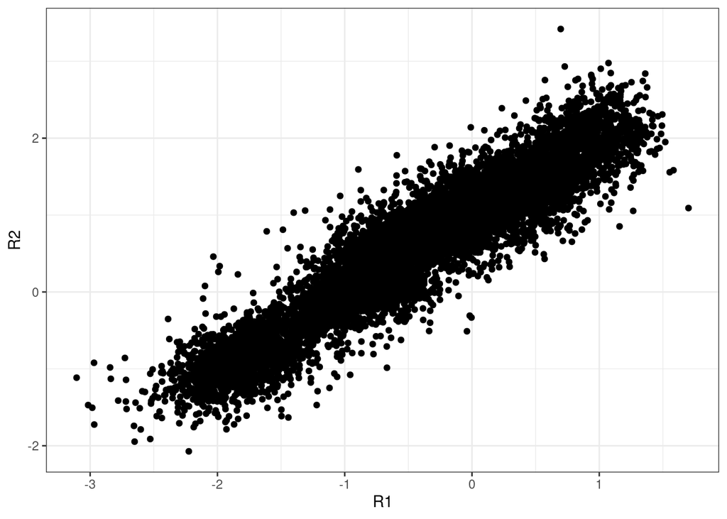

```r
# Dcast table
dcast_TIF <- screen.data.names.tib  %>% reshape2::dcast(plate+well+barcode+gene ~ rep, value.var = "log2TIF")

ggplot(dcast_TIF) + geom_point(aes(R1,R2)) + theme_bw()
```

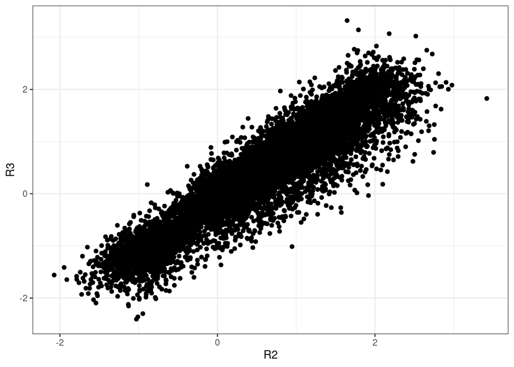

```r
ggplot(dcast_TIF) + geom_point(aes(R2,R3)) + theme_bw()
```

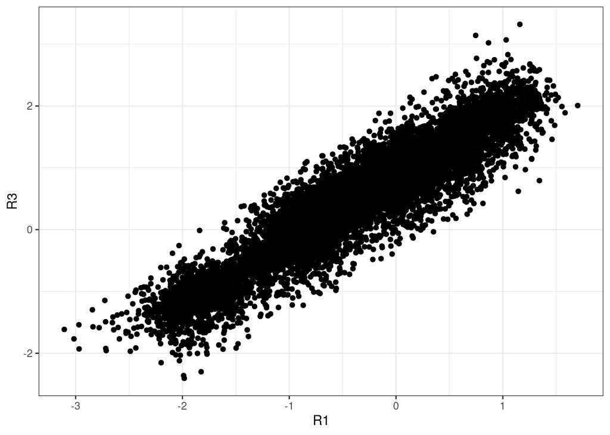

```r
ggplot(dcast_TIF) + geom_point(aes(R1,R3)) + theme_bw()
```

```r
#Reproducibility per well
dcast_well <- screen.data.names.tib %>% dplyr::group_by(plate,well,gene,rep) %>% dplyr::summarise(m = mean(log2_TIF, na.rm = T)) %>% reshape2::dcast(plate+well+gene ~ rep, value.var = "m")
```

### Calculation of differentials of log2 MMEJ:NHEJ (Formula #3)

```r
#Extract non-targetting samples from this dataset
wt.set.editing <- filter(screen.data.names.tib , sample == "WT") %>% dplyr::group_by(barcode, rep) %>% dplyr::summarise(wt.TIF = mean(log2TIF, na.rm = T))

# Compute log2 fold changes in different set ups for all the KO samples
log2.distance.TIF <- screen.data.names.tib %>%
  na.omit() %>% #Remove NA
  left_join(wt.set.editing, by = c("rep", "barcode")) %>% #Join mock KOs
  mutate(log2.foldchange = log2TIF - wt.TIF) %>% #Calculate differential of log2MMEJ:NHEJ
  dplyr::group_by(gene,well,plate,barcode,sample) %>% #Group by sample
  dplyr::summarise(mean.log2foldchange = mean(log2.foldchange,na.rm = T), n_rep = n()) %>% #Compute differential of log2MMEJ:NHEJ
  ungroup()

#Import results from screen
data_DR_screen <- read_xlsx("/home/x.vergara/XV_P3_ChromDSBScreen/xv_CRISPR_screen_figures/data/supplementary_tables/xv20220819_Table_S7a_global_CCD_MMEJ_NHEJ_results.xlsx")
effect_types <- data_DR_screen %>%
  mutate(pathway_involved = case_when(!is.na(DR_effect_type) & global_diff > 0 ~ "NHEJ",
                                      !is.na(DR_effect_type) & global_diff < 0 ~ "MMEJ")) %>%
           select(gene,DR_effect_type,pathway_involved) %>% distinct()
```

#Step 4: Identification of DR proteins with global effects on TIF

```r
#Compute mean MMEJ:NHEJ differential over all IPRs
mean.diff.TIF <- log2.distance.TIF %>%
#  filter(sample == "KO") %>%
  group_by(gene) %>%
  dplyr::summarise(mean.fc = mean(mean.log2foldchange, na.rm = T), sd = sd(mean.log2foldchange, na.rm = T))

#Join with TIF
log2TIF <- left_join(mean.diff.TIF, effect_types) %>% mutate(no_effect = is.na(DR_effect_type))
TIF_test <- t_test(log2TIF, mean.fc ~ no_effect)


#Run t.test with all the data
test.mean.diff.TIF <- log2.distance.TIF %>%
#  filter(sample == "KO") %>%
  dplyr::group_by(gene, well,plate) %>%
  t_test(mean.log2foldchange ~ 0) %>%
  mutate(p.adj = stats::p.adjust(p, method = "BH")) %>%
  left_join(mean.diff.TIF, by = "gene")

#Prepare data frame for export
mean.diff.TIF.export <- test.mean.diff.TIF %>%
  dplyr::select(gene,p,p.adj,mean.diff.TIF = mean.fc) %>% left_join(effect_types) %>% mutate(no_effect = is.na(DR_effect_type))

#Significant MMEJ
mean_significant_decrease<- filter(mean.diff.TIF.export, p.adj < 0.001 & mean.diff.TIF < 0) %>% nrow()
mean_significant_increase <- filter(mean.diff.TIF.export, p.adj < 0.001 & mean.diff.TIF > 0) %>% nrow()

#Print
print(paste("A total of", mean_significant_increase, "DR proteins increase TIF globally with an FDR < 0.001"))
```

```
## [1] "A total of 57 DR proteins increase TIF globally with an FDR < 0.001"
```

```r
print(paste("A total of", mean_significant_decrease, "DR proteins decrease TIF globally with an FDR < 0.001"))
```

```
## [1] "A total of 344 DR proteins decrease TIF globally with an FDR < 0.001"
```

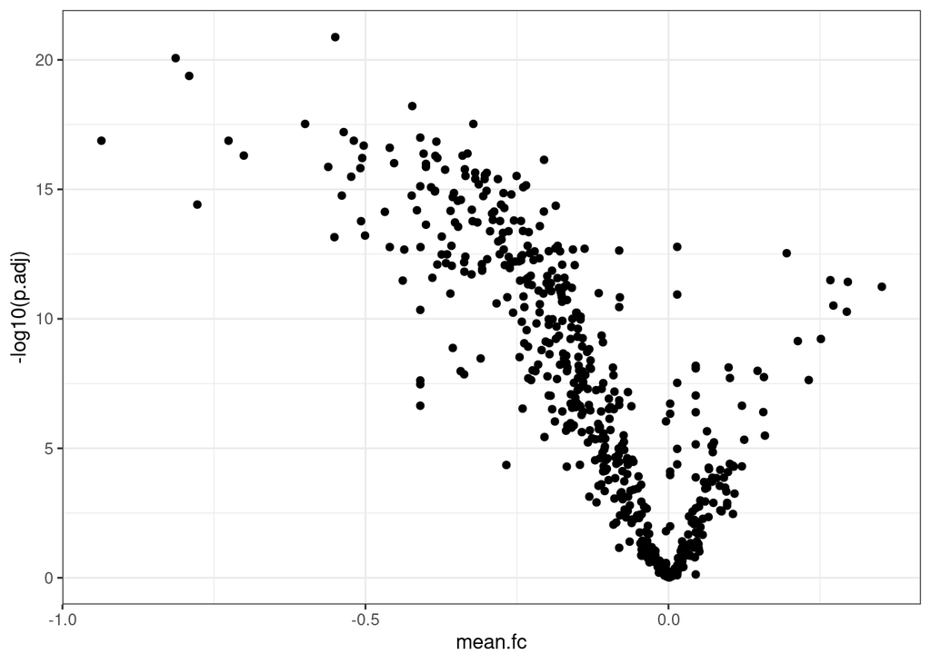

```r
#PLOT
ggplot(test.mean.diff.TIF) + geom_point(aes(mean.fc,-log10(p.adj))) + theme_bw()
```

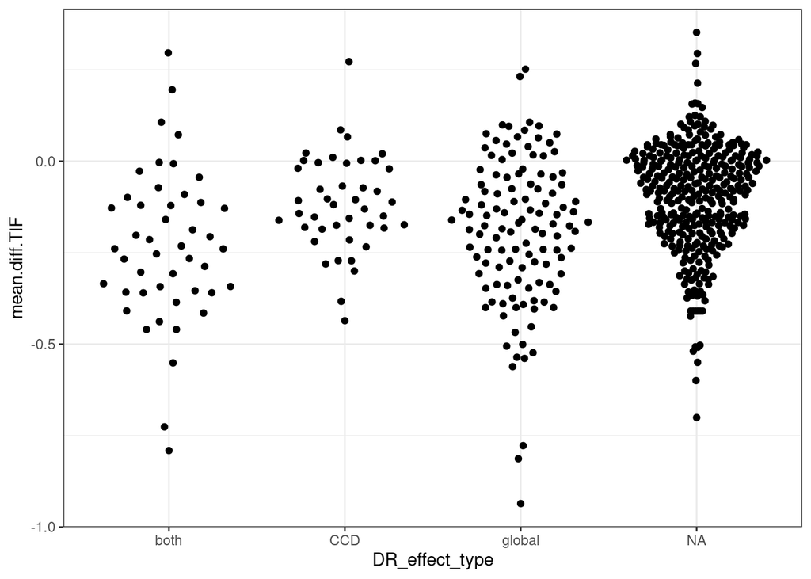

```r
# Plot TIF differences by effect
ggplot(mean.diff.TIF.export, aes(DR_effect_type,mean.diff.TIF)) +
  geom_quasirandom() +
  theme_bw()
```

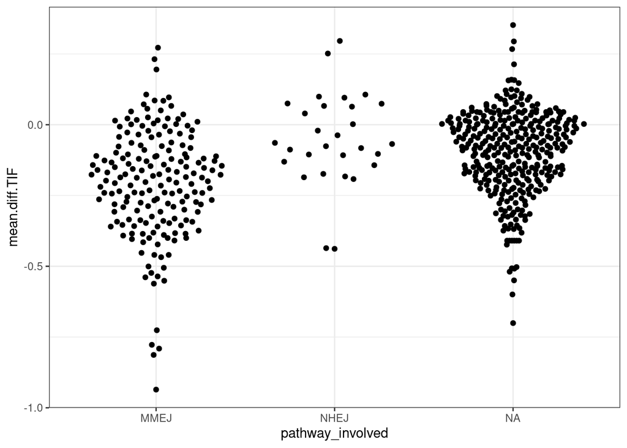

```r
# Plot TIF differences by effect
ggplot(mean.diff.TIF.export, aes(pathway_involved,mean.diff.TIF)) +
  geom_quasirandom() +
  theme_bw()
```

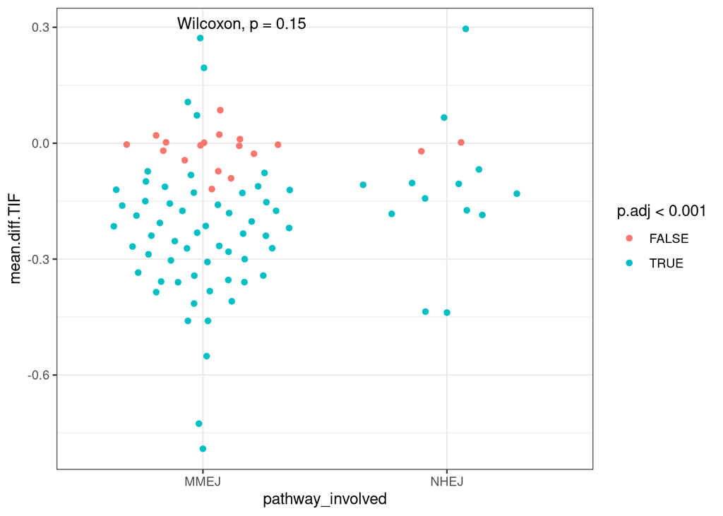

```r
# Plot TIF differences by effect
ggplot(mean.diff.TIF.export %>% filter(DR_effect_type %in% c("both","CCD")), aes(pathway_involved,mean.diff.TIF)) +
  geom_quasirandom(aes(color = p.adj < 0.001)) +
  ggpubr::stat_compare_means() +
  theme_bw()
```

#CONCLUSION: Proteins that have any type of effect tend to have lower editing efficiency. But, there is no bias between cell favoring NHEJ or MMEJ.

# Reviewer question should be addressed here!

# Check if CCDs of proteins can be explained by changes in TIF

## Sub-step A: Selection of DR proteins with Effects on MMEJ:NHEJ balance

```r
#Filter mock transfected samples
WT.values <- filter(screen.data.names.tib , sample == "WT")

#Create empty table to store mean and sd
mean_sd_fits <- tibble(term = NA, estimate = NA, std.error = NA, barcode = NA, rep = NA)

#Function to fit normal distribution through data
for (i in unique(WT.values$rep)) {
  for (x in unique(WT.values$barcode)) {
    single_wt_TIF <- filter(WT.values, rep == i & barcode == x) %>% pull(log2TIF)
    mean_sd_fits_row <- fitdistr(single_wt_TIF, "normal") %>% tidy()
    mean_sd_fits <- mean_sd_fits %>% add_row(mean_sd_fits_row %>% mutate(barcode = x, rep = i))
  }
}

#Transform the fitted values
fit.null.distribtution.log2TIF <- mean_sd_fits %>%
  reshape2::dcast(barcode + rep ~ term, value.var = "estimate") %>%
  dplyr::select(barcode, rep, wt.log2TIF = mean, sd.wt.log2TIF = sd)

# Calculate z-scores per IPR-KO combinations with the mean and sd calculated previously
fit.z.scores.TIF.IPR <- screen.data.names.tib %>%
  filter(sample %in% c("KO","WT")) %>%
  left_join(fit.null.distribtution.log2TIF, by = c("barcode", "rep")) %>% #Join null distribution mean and sd
  na.omit() %>% #remove NA
  mutate(z.score.log2TIF = (log2TIF - wt.log2TIF)/sd.wt.log2TIF) %>% #calculate z-score value
  dplyr::select(rep, gene, barcode,z.score.log2TIF,sample, well,plate) # select important variables


#Combine replicates
fit.z.scores.TIF.mean <- fit.z.scores.TIF.IPR %>%
  dplyr::group_by(gene,barcode,sample,well,plate) %>%
  dplyr::summarise(mean.z.score.IPR = sum(z.score.log2TIF, na.rm = T)/sqrt(n()), count = n()) #combine replicates and check how many values we have for each

#Summary table how many computations were selected
summary_z_score_TIF <- filter(fit.z.scores.TIF.mean, abs(mean.z.score.IPR) > 1.96) %>%
  dplyr::group_by(sample) %>%
  dplyr::summarise(count = n())


# Filter z-scores with two significant IPRs in at least 2 replicates
fit.z.scores.TIF.IPR.filtered <- filter(fit.z.scores.TIF.mean, abs(mean.z.score.IPR) > 1.96 & count > 1) %>% #Filter barcodes that meet criteria
  dplyr::group_by(gene, sample,well,plate) %>%
  dplyr::summarise(lowTIF_signif = sum(mean.z.score.IPR < -1.96), #Summarise number of significant barcodes per gene and either they favor NHEJ or MMEJ
                   highTIF_signif = sum(mean.z.score.IPR > 1.96)) %>%
  filter(lowTIF_signif > 1 | highTIF_signif > 1) %>% #Filter that significantly perturbs more than one IPR
  mutate(pathway_signif = case_when(lowTIF_signif <= 1 & highTIF_signif > 1 ~ "high_TIF", #Annotate if a protein favors NHEJ, MMEJ or both
                                    highTIF_signif <= 1 & lowTIF_signif > 1 ~ "low_TIF",
                                    T ~ "both"))

#Summary values
summary_IPR_values <- fit.z.scores.TIF.IPR.filtered %>% dplyr::group_by(pathway_signif, sample) %>% dplyr::summarise(counts = n())
total_IPR <- fit.z.scores.TIF.IPR.filtered %>% dplyr::group_by(sample) %>% dplyr::summarise(counts = n()) %>% mutate(pathway_signif = "total")
IPR_values <- bind_rows(summary_IPR_values,total_IPR) %>% reshape2::dcast(pathway_signif ~ sample, fill = 0) %>% dplyr::select("Pathway_favored" = pathway_signif, KO, "mock_KO" = WT)

#Print summary
print(IPR_values)
```

```
##   Pathway_favored  KO mock_KO
## 1            both   1       0
## 2        high_TIF  17       3
## 3         low_TIF 287       3
## 4           total 305       6
```

# Substep B: Principal component regression to identify repair proteins with CCDs

```r
#Filter genes that do not significantly perturb balance and add chromatin info
DDR.KO.CCD.dt <- log2.distance.TIF %>%
  filter(sample == "KO") %>%
  left_join(clone5_z.score_chrom_tib, by = c("barcode" = "ID")) %>% #Join chromatin info
  left_join(fit.z.scores.TIF.IPR.filtered, by = c("gene", "well", "plate","sample")) %>% na.omit() #Filter genes that do not perturb MMEJ:NHEJ balance

#Create an empty dt with CCDs of DDR proteins
DDR_KO_CCDs_dt <- tibble(gene = NA, r.squared = NA, adj.r.squared = NA,p.value = NA)

for (i in unique(DDR.KO.CCD.dt$gene)){
gene.library.dt <- filter(DDR.KO.CCD.dt, gene == i)
set.seed(1)
PCR_model_DDR_test <- pcr(mean.log2foldchange~CTCF+EZH2+H2AFZ+H3K27ac+H3K27me3+H3K36me3+H3K4me1+H3K4me2+H3K4me3+H3K79me2+H3K9me2+H3K9me3+H4K5acK8ac+HDAC1+HDAC2+HDAC3+POL2+POL2AS2+SMC3+LMNB1+Dam+DNAse+m5C+late_replicating+TTseq, data=gene.library.dt , validation="CV") #Run principal component regression

pcr_pred <- predict(PCR_model_DDR_test, gene.library.dt, ncomp = 3) #Run model with three PC
combined.dt <- tibble(measured = gene.library.dt$mean.log2foldchange, predicted = as.numeric(pcr_pred)) #Create table with real and predicted differentials
pred_vs_estim <- lm(formula = measured ~ predicted, data = combined.dt) %>% glance() #Predicted vs. measured correlation plot
DDR_KO_CCDs_dt <- DDR_KO_CCDs_dt %>% add_row(gene = i, r.squared = pred_vs_estim %>% pull(r.squared), adj.r.squared = pred_vs_estim %>% pull(adj.r.squared), p.value = pred_vs_estim %>% pull(p.value)) #Extract valuable metrics
}
```

#Quality control. Empirical false discovery rate. Run the model for mock KO samples

```r
#Select WT
WT.z.score.filter <- fit.z.scores.TIF.IPR.filtered %>% filter(sample == "WT")

#Average all replicates and prepare data to compute CCDs and global effects
DDR.NT.CCD.dt <- log2.distance.TIF %>%
  filter(sample == "WT") %>%
  right_join(WT.z.score.filter) %>%
  dplyr::group_by(gene,well,plate,barcode) %>%
  mutate(coordinate = paste0(plate,"_",well)) %>%
  left_join(clone5_z.score_chrom_tib, by = c("barcode" = "ID"))


#DDR library non-targetting controls (n = 33)
DDR_NT_CCDs_model <- tibble(gene = NA, r.squared = NA, adj.r.squared = NA,p.value = NA)

for (i in unique(DDR.NT.CCD.dt$coordinate)){
gene.library.dt <- filter(DDR.NT.CCD.dt, coordinate == i)
# Run a model per gene
set.seed(1)
PCR_model_DDR_test <- pcr(mean.log2foldchange~CTCF+EZH2+H2AFZ+H3K27ac+H3K27me3+H3K36me3+H3K4me1+H3K4me2+H3K4me3+H3K79me2+H3K9me2+H3K9me3+H4K5acK8ac+HDAC1+HDAC2+HDAC3+POL2+POL2AS2+SMC3+LMNB1+Dam+DNAse+m5C+late_replicating+TTseq, data=gene.library.dt , validation="CV") #Run PCR with several components

pcr_pred <- predict(PCR_model_DDR_test, gene.library.dt, ncomp = 3) #Predict the values using three components
combined.dt <- tibble(measured = gene.library.dt$mean.log2foldchange, predicted = as.numeric(pcr_pred))
pred_vs_estim <- lm(formula = measured ~ predicted, data = combined.dt) %>% glance() #Run a linear model predicted vs. measured and extract p-value
DDR_NT_CCDs_model <- DDR_NT_CCDs_model %>% add_row(gene = i, r.squared = pred_vs_estim %>% pull(r.squared), adj.r.squared = pred_vs_estim %>% pull(adj.r.squared), p.value = pred_vs_estim %>% pull(p.value))
}
```

#Bind both and correct p-value

```r
#non-targeting (2 non-targeting values are selected with this value)
adj_p.value_model <- DDR_NT_CCDs_model %>% mutate(sample = "WT") %>%
  bind_rows(DDR_KO_CCDs_dt %>%
              mutate(sample = "KO")) %>%
  na.omit() %>%
  dplyr::select(p.value, gene,sample)  %>%
  mutate(p.adj = p.adjust(p.value, method = "BH")) %>%
  dplyr::select(gene,p.value,p.adj, sample)

#Check the number of significant hits per WT and KO
samples_significant_CCDs <- adj_p.value_model %>%
  filter(p.adj < 0.05) %>% #5% FDR
  dplyr::group_by(sample) %>%
  dplyr::summarise(counts = n())#3 mock values have significant CCDs (9% of total proteins) & 158 KO proteins

#Do these proteins favor MMEJ or NHEJ
summary_genes <- adj_p.value_model %>%
  filter(p.adj < 0.05 & sample == "KO") %>% #5% FDR
  left_join(fit.z.scores.TIF.IPR.filtered) %>%
  dplyr::group_by(pathway_signif) %>%
  dplyr::summarise(count = n())

#Print
print(paste("We identified a total of",samples_significant_CCDs[1,"counts"], "DR proteins with significant CCD with a estimated FDR 5%"))
```

```
## [1] "We identified a total of 170 DR proteins with significant CCD with a estimated FDR 5%"
```

```r
print(paste("We empirically tested the FDR and found that ",samples_significant_CCDs[2,"counts"], " out of 33 mock KO samples (9%) were called significant which is a bit higher than expected"))
```

[output not shown]

#Sub-step C: Linear modeling to identify individual DR proteins - chromatin feature links

```r
#Create empty dataframe to calculate synergy scores
DR_KO_CCD_slopes <- tibble(gene = NA, feature = NA, slope.log2 = NA, term = NA,p.value = NA)

#Loop to run linear models on the values
for (h in unique(DDR.KO.CCD.dt$gene)) {
  for (j in colnames(DDR.KO.CCD.dt)[10:34]) { #Run this function for each of the 25 high quality chromatin features
    model.dt <- DDR.KO.CCD.dt %>% filter(gene == h) # And For each gene
   if (nrow(model.dt) == 0) {
next
}
    model.epistasis.log2 <- lm(formula = mean.log2foldchange ~ unlist(model.dt[j]), data = model.dt) %>% tidy() #Correlation analysis
   DR_KO_CCD_slopes <- DR_KO_CCD_slopes %>% add_row(gene = h, feature = j, slope.log2 = model.epistasis.log2 %>% pull(estimate), term = model.epistasis.log2 %>% pull(term), p.value = model.epistasis.log2 %>% pull(p.value)) #Select valuable parameters and save them in data frame
  }
}

#Retain slopes that
DR_KO_CCD_all_values <- DR_KO_CCD_slopes %>%
  reshape2::dcast(gene + feature ~ term, value.var = "slope.log2") %>%  #dcast table
  dplyr::select(gene ,feature,intercept = '(Intercept)', slope = 'unlist(model.dt[j])') %>% #Extract information for slopes only
  left_join(adj_p.value_model %>%
              dplyr::select(gene, model_p.value = p.value, model_p.adj = p.adj), by = "gene") %>% #Join with CCDs p_value data table and change some names
  left_join(fit.z.scores.TIF.IPR.filtered, by = "gene") %>% #Join with individual IPR significance calls (z-test)
  mutate(CCD_value = case_when(pathway_signif == "low_TIF" & slope < 0 ~ slope, pathway_signif == "low_TIF" & slope > 0 ~ 0, pathway_signif == "high_TIF" & slope > 0 ~ slope, pathway_signif == "high_TIF" & slope < 0 ~ 0, T ~ slope)) %>% #Call M-synergies, N-synergies or no synergies based on the slope and MMEJ:NHEJ differentials
  na.omit()

#How many M-, N- and no synergies
synergy_summaries <- DR_KO_CCD_all_values %>% filter(model_p.adj < 0.05) %>% dplyr::group_by(gene) %>% dplyr::summarise(lowTIF_synergy = sum(CCD_value < 0), highTIF_synergy = sum(CCD_value > 0)) %>% distinct() %>% mutate(synergy_class = case_when(highTIF_synergy == 0 ~ "lowTIF_synergy", lowTIF_synergy == 0 ~ "highTIF_synergy", T ~ "both")) %>% dplyr::group_by(synergy_class) %>% dplyr::summarise(c = n())
```